# Baseline Models for Collaborative Filtering

#### Part 2 of the MovieLens Project series

##### Previous articles

- Exploratory Data Analysis of MovieLens Dataset

##### Next articles

- Recommending Movies with Similarity-Based Collaborative Filtering
- Recommending Movies with Alternating Least Squares
- Recommending Movies with Stochastic Gradient Descent
- Comparing Collaborative Filtering Models

This is the second post of a project on collaborative filtering based on the MovieLens 100K dataset. The remainder of this post is straight out of a Jupyter Notebook file you can download here. You can also see it [here](https://github.com/benlindsay/movielens-analysis/blob/master/02_Baselines.ipynb) on GitHub.

Baseline models are important for 2 key reaons:

1. Baseline models give us a starting point to which to compare all future models, and
2. Smart baselines/averages may be needed to fill in missing data for more complicated models

Here, we'll explore a few typical baseline models for recommender systems and see which ones do the best for our dataset.

Expand Code

# 1. Load the Data

Let's load and examine the ratings data. If you're following along (i.e. actually running these notebooks) you'll need to make sure to run the first one to download the data before running this one.

Expand Code

```
First 5:
```

|  | userId | movieId | rating | timestamp |
| --- | --- | --- | --- | --- |
| 214 | 259 | 255 | 4 | 1997-09-19 23:05:10 |
| 83965 | 259 | 286 | 4 | 1997-09-19 23:05:27 |
| 43027 | 259 | 298 | 4 | 1997-09-19 23:05:54 |
| 21396 | 259 | 185 | 4 | 1997-09-19 23:06:21 |
| 82655 | 259 | 173 | 4 | 1997-09-19 23:07:23 |

```
Last 5:
```

|  | userId | movieId | rating | timestamp |
| --- | --- | --- | --- | --- |
| 46773 | 729 | 689 | 4 | 1998-04-22 19:10:38 |
| 73008 | 729 | 313 | 3 | 1998-04-22 19:10:38 |
| 46574 | 729 | 328 | 3 | 1998-04-22 19:10:38 |
| 64312 | 729 | 748 | 4 | 1998-04-22 19:10:38 |
| 79208 | 729 | 272 | 4 | 1998-04-22 19:10:38 |

# 2. Test Baseline Models

With all that framework setup out of the way, let's evaluate a few baseline models in increasing order of expected accuracy.

## 2.1 Simple Average Model

The first model we'll test is about the simplest one possible. We'll just average all the training set ratings and use that average for the prediction for all test set examples.

Expand Code

## 2.2 Average by ID Model

We can probably do a little better by using the user or item (movie) average. Here we'll set up a baseline model class that allows you to pass either a list of `userId`s or `movieId`s as `X`. The prediction for a given ID will just be the average of ratings from that ID, or the overall average if that ID wasn't seen in the training set.

Expand Code

## 2.3 Damped Baseline with User + Movie Data

This baseline model takes into account the average ratings of both the user and the movie, as well as a damping factor that brings the baseline prediction closer to the overall mean. The damping factor has been shown empirically to improve the perfomance.

This model follows equation 2.1 from a [collaborative filtering paper](http://files.grouplens.org/papers/FnT%20CF%20Recsys%20Survey.pdf) from [GroupLens](https://grouplens.org/), the same group that published the MovieLens data. This equation defines rhe baseline rating for user $u$ and item $i$ as

$$b_{u,i} = \mu + b_u + b_i$$

where

$$b_u = \frac{1}{|I_u| + \beta_u}\sum_{i \in I_u} (r_{u,i} - \mu)$$

and

$$b_i = \frac{1}{|U_i| + \beta_i}\sum_{u \in U_i} (r_{u,i} - b_u - \mu).$$

(See equations 2.4 and 2.5). Here, $\beta_u$ and $\beta_i$ are damping factors, for which the paper reported 25 is a good number for this dataset. For now we'll just leave these values equal ($\beta=\beta_u=\beta_i$). Here's a summary of the meanings of all the variables here:

| Variable | Meaning |
| --- | --- |
| $b_{u,i}$ | Baseline rating for user $u$ on item (movie) $i$ |
| $\mu$ | The mean of all ratings |
| $b_u$ | The deviation from $\mu$ associated with user $u$ |
| $b_i$ | The deviation from $\mu+b_u$ associated with user $i$ |
| $I_u$ | The set of all items rated by user $u$ |
| $\mid I_u \mid$ | The number of items rated by user $u$ |
| $\beta_u$ | Damping factor for the users ($=\beta$) |
| $r_{u,i}$ | Observed rating for user $u$ on item $i$ |
| $U_i$ | The set of all users who rated item $i$ |
| $\mid U_i \mid$ | The number of users who rated item $i$ |
| $\beta_i$ | Damping factor for the items ($=\beta$) |

Expand Code

## 2.4 Cross-validation framework

Because the ratings distributions look relatively unchanged over time, we will use a time-independent cross-validation framework to determine the best baseline model moving forward. Below we define `get_xval_errs()` such that if you pass in a dataframe and a baseline model object, it will return a list of the 5 (or `n_splits`) Mean Absolute Error (MAE) values from each fold.

```python
def get_xval_errs_and_res(df, model, n_splits=5, random_state=0, rating_col='rating'):
    kf = KFold(n_splits=n_splits, random_state=random_state, shuffle=True)
    errs, stds = [], []
    residuals = np.zeros(len(df))
    for train_inds, test_inds in kf.split(df):
        train_df, test_df = df.iloc[train_inds], df.iloc[test_inds]
        pred = model.fit(train_df).predict(test_df)
        residuals[test_inds] = pred - test_df[rating_col]
        mae = mean_absolute_error(pred, test_df[rating_col])
        errs.append(mae)
    return errs, residuals
```

Expand Code

|  | Average | Item Average | User Average | Combined 0 | Combined 10 | Combined 25 | Combined 50 |
| --- | --- | --- | --- | --- | --- | --- | --- |
| 0 | 0.938915 | 0.811093 | 0.831037 | 0.755218 | 0.755246 | 0.761931 | 0.773639 |
| 1 | 0.953741 | 0.825894 | 0.842430 | 0.763540 | 0.764793 | 0.772484 | 0.785081 |
| 2 | 0.945107 | 0.814342 | 0.837044 | 0.757141 | 0.757230 | 0.764379 | 0.776727 |
| 3 | 0.937957 | 0.813231 | 0.829171 | 0.752095 | 0.751890 | 0.759048 | 0.771349 |
| 4 | 0.947786 | 0.820604 | 0.835589 | 0.759378 | 0.758553 | 0.765714 | 0.778648 |

|  | Average | Item Average | User Average | Combined 0 | Combined 10 | Combined 25 | Combined 50 |
| --- | --- | --- | --- | --- | --- | --- | --- |
| 99995 | -0.469975 | -0.818182 | -1.312500 | -1.685529 | -1.309622 | -1.064009 | -0.879723 |
| 99996 | 0.529288 | 1.257840 | -0.250000 | 0.470216 | 0.745825 | 0.889503 | 0.957703 |
| 99997 | 0.529288 | 0.434211 | -0.250000 | -0.315062 | -0.012279 | 0.166903 | 0.286514 |
| 99998 | -0.469762 | -0.850202 | -1.222222 | -1.576204 | -1.296998 | -1.111291 | -0.969507 |
| 99999 | -0.469975 | 0.222222 | -1.312500 | -0.585790 | -0.313551 | -0.185635 | -0.140248 |

Expand Code

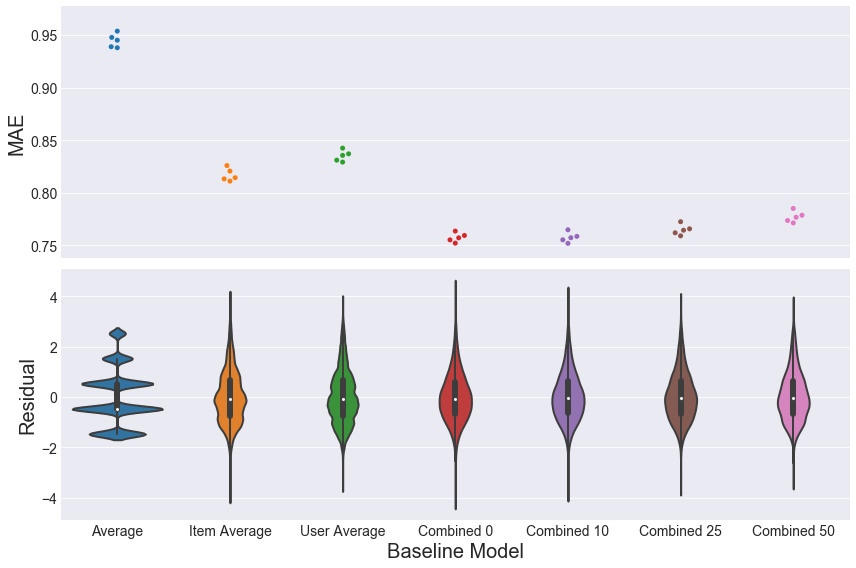

Before moving on to collaborative filtering models, we'll want to choose which model to use as a baseline. Both the Combined 0 and Combined 10 models performed equally, but we'll choose the Combined 10 model, because a higher damping factor is effectively stronger regularization, which will prevent overfitting better than a damping factor of 0.

Check out the next post/notebook to see collaborative filtering models building on these baselines!

#### Part 2 of the MovieLens Project series

##### Previous articles

- Exploratory Data Analysis of MovieLens Dataset

##### Next articles

- Recommending Movies with Similarity-Based Collaborative Filtering
- Recommending Movies with Alternating Least Squares
- Recommending Movies with Stochastic Gradient Descent
- Comparing Collaborative Filtering Models

## Comments

[comments powered by Disqus](https://disqus.com)